# InVivoStat Unpaired t-test Analysis

## Response

The Resp 1 response is currently being analysed by the Unpaired t-test Analysis module.

For more information on the theoretical approaches that are implemented within this module, see Bate and Clark (2014).

## Scatterplot of the observed data

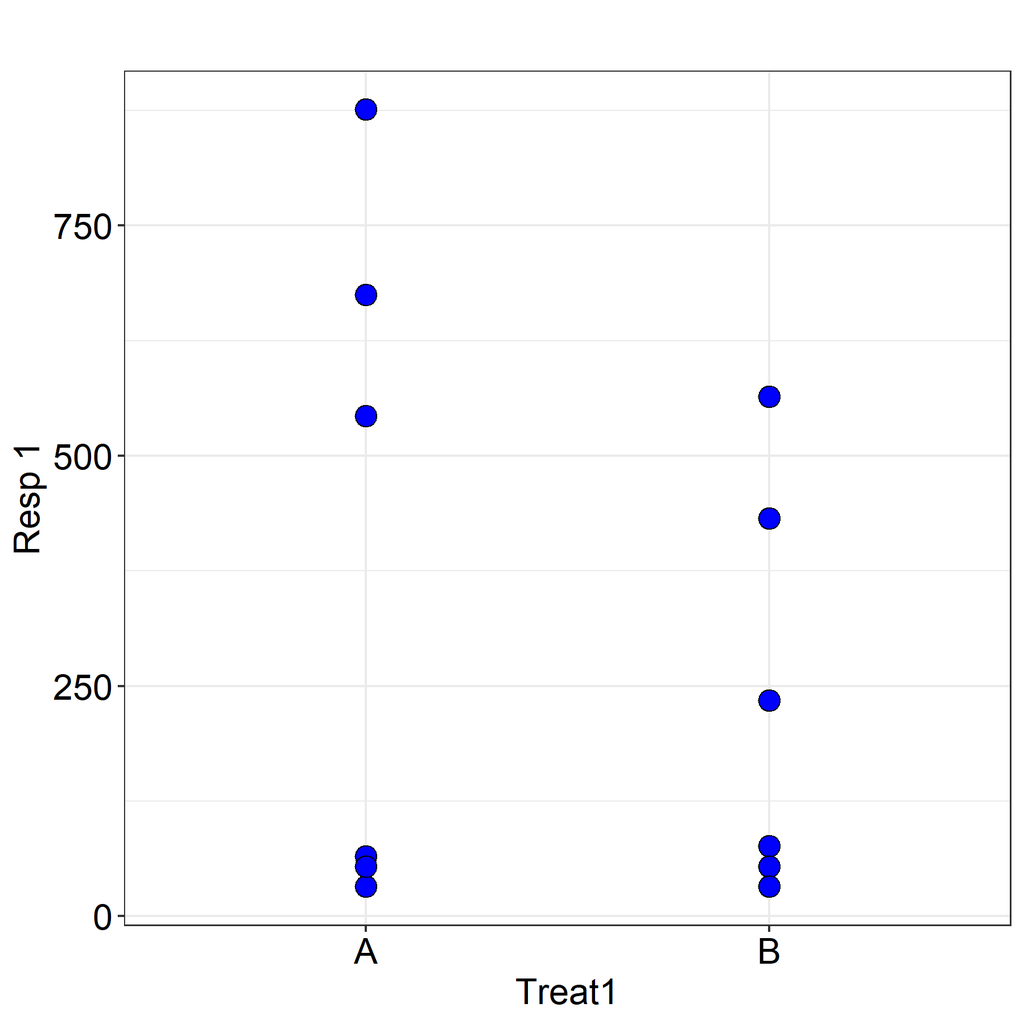

Tip: Use this plot to identify possible outliers.

## Statistical analysis results assuming equal variances

### Unpaired t-test result

|  | t-statistic | Degrees of freedom | p-value |
| --- | --- | --- | --- |
| Equal variance unpaired t-test | 0.806 | 10 | 0.4387 |

Conclusion: At the 5% level, the difference between the levels of Resp 1 is not statistically significant.

### Table of the least square (predicted) means with 95% confidence intervals

| Treatment level | Mean | Lower 95% CI | Upper 95% CI |
| --- | --- | --- | --- |
| A | 374.167 | 96.429 | 651.904 |
| B | 232.000 | -45.738 | 509.738 |

### Comparison of the least square (predicted) means with 95% confidence interval

| Comparison | Difference | Lower 95% CI | Upper 95% CI | Std error | p-value |
| --- | --- | --- | --- | --- | --- |
| A - B | 142.167 | -250.614 | 534.947 | 176.282 | 0.4387 |

## Diagnostic plots (assuming equal variances)

### Residuals vs. predicted plot

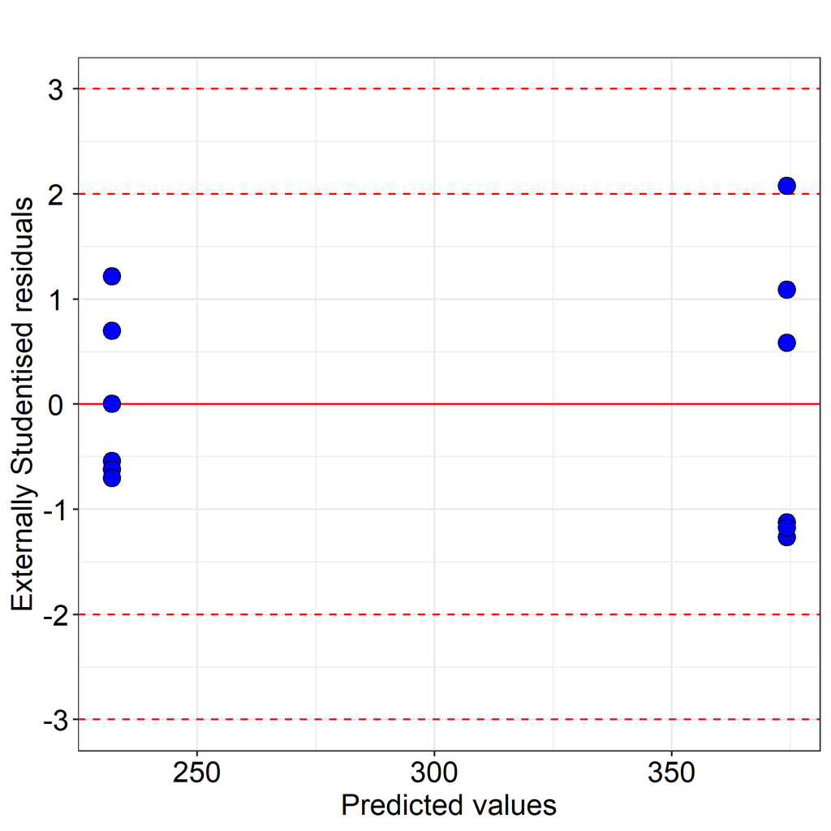

Tip: On this plot look to see if the spread of the points increases as the predicted values increase. If so the response may need transforming or the unequal variance assumption selected.

Tip: Any observation with a residual less than -3 or greater than 3 (SD) should be investigated as a possible outlier.

### Normal probability plot

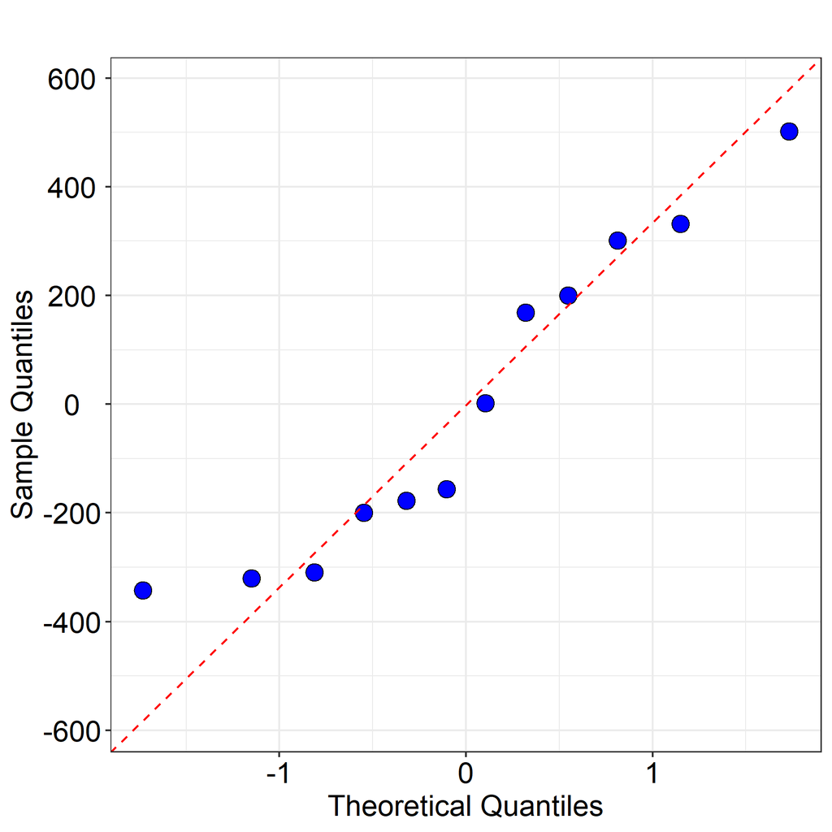

Tip: Check that the points lie along the dotted line. If not then the data may be non-normally distributed.

## Statistical analysis results assuming unequal variances

The analysis presented is Welch's t-test assuming unequal variances, Welch (1947).

### Unpaired t-test result

|  | t-statistic | Degrees of freedom | p-value |
| --- | --- | --- | --- |
| Unequal variance unpaired t-test | 0.806 | 8.18 | 0.4428 |

Conclusion: At the 5% level, the difference between the levels of Resp 1 is not statistically significant.

## Diagnostic plots (assuming unequal variances)

### Residuals vs. predicted plot

This plot is not available for the unequal variance case.

### Normal probability plot

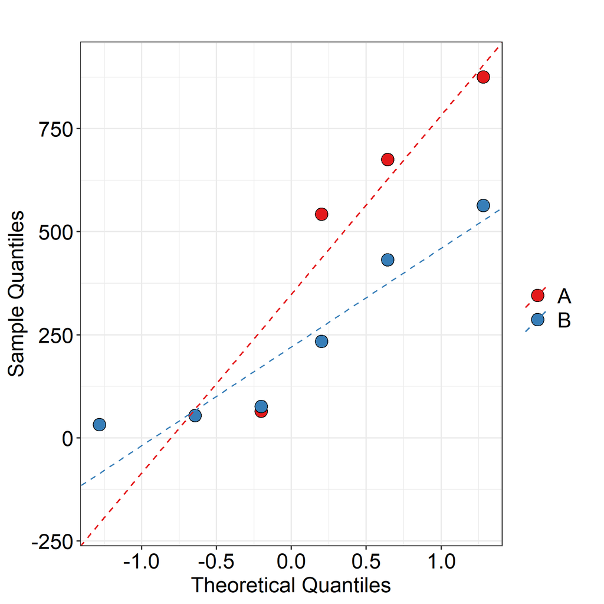

Note: The normal probability plot includes one line per group as the variances are estimated separately for each group.

Tip: Check that the points lie along the dotted line. If not then the data may be non-normally distributed.

### Table of the least square (predicted) means with 95% confidence intervals

| Treatment level | Mean | Lower 95% CI | Upper 95% CI |
| --- | --- | --- | --- |
| A | 374.167 | -14.553 | 762.886 |
| B | 232.000 | -0.893 | 464.893 |

### Comparison of the least square (predicted) means with 95% confidence interval

| Comparison | Difference | Lower 95% CI | Upper 95% CI | p-value |
| --- | --- | --- | --- | --- |
| A - B | 142.167 | -262.790 | 547.123 | 0.4428 |

## References

When referring to InVivoStat, please cite 'InVivoStat, version 5.2.0'.

Bate, S.T. and Clark, R.A. (2014). The Design and Statistical Analysis of Animal Experiments. Cambridge University Press.

Welch, B.L. (1947). The generalization of Student's problem when several different population variances are involved. Biometrika, 34(1-2), 28-35.